# Python Libraries for Data Analytics & Data Science

```python
import numpy as np
np.array([1, 2, 3])
```

```
array([1, 2, 3])
```

**numpy arrays** share many properties with Python lists

```python
a = np.array([1, 3, 2])
len(a)
a.sort()
a
```

```
array([1, 2, 3])
```

**arange** : In analogy with the list range() function, we can create array ranges in NumPy using np.arange()

```python
r = np.arange(17)
r
```

```
array([ 0,  1,  2,  3,  4,  5,  6,  7,  8,  9, 10, 11, 12, 13, 14, 15, 16])
```

Computations with numpy arrays are **much faster** than the corresponding operations with lists. Because NumPy itself is array-based, such computations **can also typically be expressed much more compactly**, without the need for loops or even comprehensions. In particular, NumPy arrays support vectorized operations, whereby we can (say) multiply every element in an array by a particular number all at once.

```python
[3 * i for i in r]   # This is Python can be expressed more compactly as
3 * a                # in numpy
```

```
array([3, 6, 9])
```

**timeit** - we can use the timeit library to compare execution speeds for normal Python and numpy structures. It Python let's do some heavy computation and time it:

```python
%%timeit
[i**2 for i in range(1000)]
```

```
263 μs ± 2.42 μs per loop (mean ± std. dev. of 7 runs, 1,000 loops each)
```

using numpy? -- You should see a huge difference in speeds!

```python
%%timeit
np.arange(1000)**2
```

```
1.37 μs ± 73.8 ns per loop (mean ± std. dev. of 7 runs, 1,000,000 loops each)
```

Numpy also provides support for **multi-dimensional arrays**

```python
a = np.array([[1, 2, 3], [4, 5, 6]])
a
```

```
array([[1, 2, 3],
       [4, 5, 6]])
```

# **Data Visualization with Matplotlib**

Matplotlib is a powerful visualization tool for Python that can do an absurdly large number of awesome things. The exact mechanics of getting Matplotlib plots to display varies widely depending on the exact details of your setup. The most explicit way to show plots, which works on most systems from the REPL, is to use the show() method:

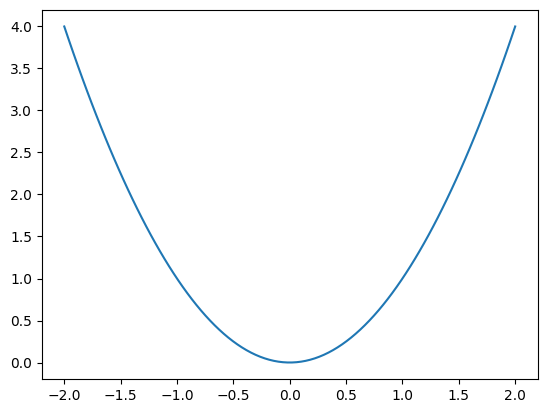

```python
import numpy as np
import matplotlib.pyplot as plt
x = np.linspace(-2, 2, 100)
fig, ax = plt.subplots(1, 1)
ax.plot(x, x*x)
plt.show()
%matplotlib inline
```

```python
import numpy as np
import matplotlib.pyplot as plt
import pandas as pd

nobel = pd.read_csv("ship_fuel_efficiency.csv")
nobel.describe()
```

|  | distance | fuel_consumption | CO2_emissions | engine_efficiency |
| --- | --- | --- | --- | --- |
| count | 1440.000000 | 1440.000000 | 1440.000000 | 1440.000000 |
| mean | 151.753354 | 4844.246535 | 13365.454882 | 82.582924 |
| std | 108.472230 | 4892.352813 | 13567.650118 | 7.158289 |
| min | 20.080000 | 237.880000 | 615.680000 | 70.010000 |
| 25% | 79.002500 | 1837.962500 | 4991.485000 | 76.255000 |
| 50% | 123.465000 | 3060.880000 | 8423.255000 | 82.775000 |
| 75% | 180.780000 | 4870.675000 | 13447.120000 | 88.862500 |
| max | 498.550000 | 24648.520000 | 71871.210000 | 94.980000 |

```python
nobel.head(10)
```

|  | ship_id | ship_type | route_id | month | distance | fuel_type | fuel_consumption | CO2_emissions | weather_conditions | engine_efficiency |
| --- | --- | --- | --- | --- | --- | --- | --- | --- | --- | --- |
| 0 | NG001 | Oil Service Boat | Warri-Bonny | January | 132.26 | HFO | 3779.77 | 10625.76 | Stormy | 92.14 |
| 1 | NG001 | Oil Service Boat | Port Harcourt-Lagos | February | 128.52 | HFO | 4461.44 | 12779.73 | Moderate | 92.98 |
| 2 | NG001 | Oil Service Boat | Port Harcourt-Lagos | March | 67.30 | HFO | 1867.73 | 5353.01 | Calm | 87.61 |
| 3 | NG001 | Oil Service Boat | Port Harcourt-Lagos | April | 71.68 | Diesel | 2393.51 | 6506.52 | Stormy | 87.42 |
| 4 | NG001 | Oil Service Boat | Lagos-Apapa | May | 134.32 | HFO | 4267.19 | 11617.03 | Calm | 85.61 |
| 5 | NG001 | Oil Service Boat | Port Harcourt-Lagos | June | 85.93 | Diesel | 2342.13 | 6753.42 | Stormy | 72.82 |
| 6 | NG001 | Oil Service Boat | Warri-Bonny | July | 85.67 | HFO | 2974.79 | 8498.16 | Moderate | 93.93 |
| 7 | NG001 | Oil Service Boat | Warri-Bonny | August | 44.81 | Diesel | 1376.38 | 3509.56 | Moderate | 91.10 |
| 8 | NG001 | Oil Service Boat | Escravos-Lagos | September | 116.44 | Diesel | 3661.75 | 9423.97 | Calm | 73.41 |
| 9 | NG001 | Oil Service Boat | Lagos-Apapa | October | 99.73 | HFO | 2551.99 | 6416.66 | Moderate | 94.68 |

```python
nobel.info()
```

```
<class 'pandas.core.frame.DataFrame'>
RangeIndex: 1440 entries, 0 to 1439
Data columns (total 10 columns):
 #   Column              Non-Null Count  Dtype
---  ------              --------------  -----
 0   ship_id             1440 non-null   object
 1   ship_type           1440 non-null   object
 2   route_id            1440 non-null   object
 3   month               1440 non-null   object
 4   distance            1440 non-null   float64
 5   fuel_type           1440 non-null   object
 6   fuel_consumption    1440 non-null   float64
 7   CO2_emissions       1440 non-null   float64
 8   weather_conditions  1440 non-null   object
 9   engine_efficiency   1440 non-null   float64
dtypes: float64(4), object(6)
memory usage: 112.6+ KB
```

Here are six potential research questions to guide the analysis:

1. What is the average fuel consumption and CO2 emissions for different ship types?
2. How does fuel consumption vary across different routes?
3. Is there a relationship between engine efficiency and fuel consumption?
4. What impact do weather conditions have on fuel consumption and CO2 emissions?
5. Which fuel type (HFO vs Diesel) has higher CO2 emissions per kilometer?
6. How does fuel consumption change over different months?

# Analyzing Average Fuel Consumption and CO2 Emissions by Ship Type

In this section, we aim to answer the first research question: **"What is the average fuel consumption and CO2 emissions for different ship types?"**

We will:

1. Group the data by `ship_type`.
2. Calculate the average fuel consumption and CO2 emissions for each ship type.
3. Visualize the results using bar plots for better understanding.

```
Summary Statistics for Fuel Consumption and CO2 Emissions by Ship Type:
```

|  | ship_type | fuel_consumption | CO2_emissions |
| --- | --- | --- | --- |
| 0 | Fishing Trawler | 3229.170933 | 8913.090600 |
| 1 | Oil Service Boat | 2619.435490 | 7187.831250 |
| 2 | Surfer Boat | 1666.133673 | 4577.636574 |
| 3 | Tanker Ship | 10780.408676 | 29795.437377 |

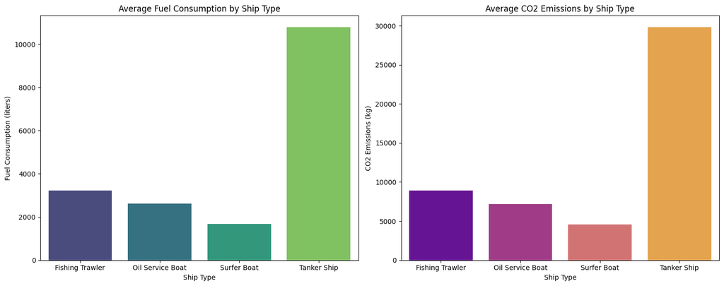

```python
import matplotlib.pyplot as plt
import seaborn as sns

file_path = 'ship_fuel_efficiency.csv'
data = pd.read_csv(file_path)

# Group the data by 'ship_type' and calculate average fuel consumption and CO2 emissions
ship_type_summary = data.groupby('ship_type')[['fuel_consumption', 'CO2_emissions']].mean().reset_index()

# Display summary table
print("Summary Statistics for Fuel Consumption and CO2 Emissions by Ship Type:")
display(ship_type_summary)

# Plot the average fuel consumption and CO2 emissions for different ship types
fig, ax = plt.subplots(1, 2, figsize=(15, 6))

# Average Fuel Consumption by Ship Type
sns.barplot(x='ship_type', y='fuel_consumption', data=ship_type_summary, hue=None, palette='viridis', ax=ax[0])
ax[0].set_title('Average Fuel Consumption by Ship Type')
ax[0].set_xlabel('Ship Type')
ax[0].set_ylabel('Fuel Consumption (liters)')

# Average CO2 Emissions by Ship Type
sns.barplot(x='ship_type', y='CO2_emissions', data=ship_type_summary, hue=None, palette='plasma', ax=ax[1])
ax[1].set_title('Average CO2 Emissions by Ship Type')
ax[1].set_xlabel('Ship Type')
ax[1].set_ylabel('CO2 Emissions (kg)')

plt.tight_layout()
plt.show()
```

# Analyzing Fuel Consumption Across Different Routes

In this section, we aim to answer the second research question: **"How does fuel consumption vary across different routes?"**

We will:

1. Group the data by `route_id` and calculate the average fuel consumption.
2. Sort the routes to identify those with the highest and lowest average fuel consumption.
3. Visualize the results using a horizontal bar plot for better readability.

```
Top Routes by Average Fuel Consumption:
```

|  | route_id | fuel_consumption |
| --- | --- | --- |
| 1 | Lagos-Apapa | 5171.549716 |
| 0 | Escravos-Lagos | 4932.468780 |
| 2 | Port Harcourt-Lagos | 4805.137301 |
| 3 | Warri-Bonny | 4353.314048 |

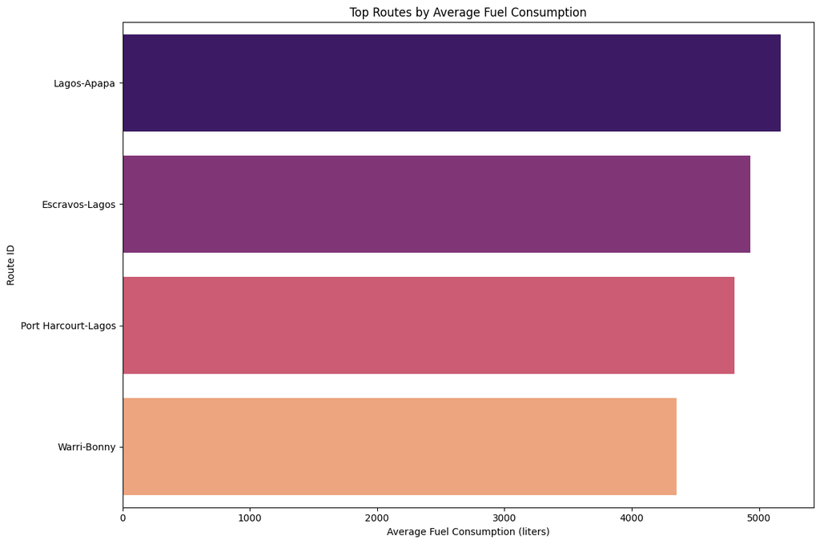

```python
import matplotlib.pyplot as plt
import seaborn as sns

# Group the data by 'route_id' and calculate average fuel consumption
route_summary = data.groupby('route_id')['fuel_consumption'].mean().reset_index()

# Sort the data by fuel consumption in descending order
route_summary = route_summary.sort_values(by='fuel_consumption', ascending=False)

# Display the top 10 routes with the highest average fuel consumption
print("Top Routes by Average Fuel Consumption:")
display(route_summary.head(10))

# Visualize the average fuel consumption across routes
plt.figure(figsize=(12, 8))

sns.barplot(x='fuel_consumption', y='route_id', data=route_summary.head(10), palette='magma', hue=None)

plt.title('Top Routes by Average Fuel Consumption')
plt.xlabel('Average Fuel Consumption (liters)')
plt.ylabel('Route ID')
plt.tight_layout()
plt.show()
```

# Analyzing Relationship Between Engine Efficiency and Fuel Consumption

In this section, we aim to answer the third research question: **"Is there a relationship between engine efficiency and fuel consumption?"**

We will:

1. Use a scatter plot to visualize the relationship between `engine_efficiency` and `fuel_consumption`.
2. Compute the correlation coefficient to measure the strength of the relationship.

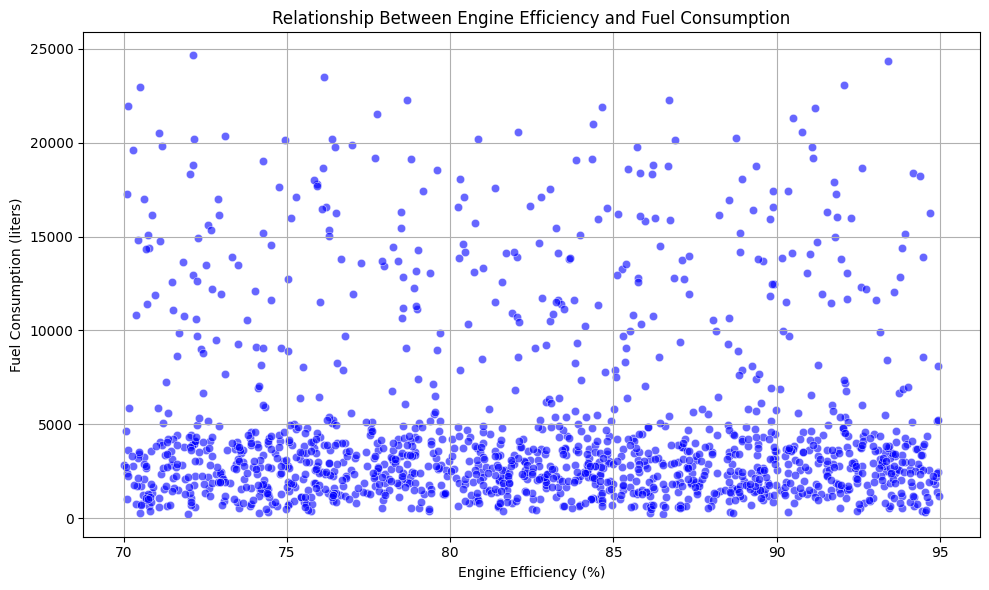

```
Correlation between Engine Efficiency and Fuel Consumption: -0.03
```

```python
import matplotlib.pyplot as plt
import seaborn as sns

# Scatter plot: Engine Efficiency vs. Fuel Consumption
plt.figure(figsize=(10, 6))
sns.scatterplot(x='engine_efficiency', y='fuel_consumption', data=data, color='blue', alpha=0.6)
plt.title('Relationship Between Engine Efficiency and Fuel Consumption')
plt.xlabel('Engine Efficiency (%)')
plt.ylabel('Fuel Consumption (liters)')
plt.grid(True)
plt.tight_layout()
plt.show()

# Calculate correlation coefficient
correlation = data['engine_efficiency'].corr(data['fuel_consumption'])
print(f"Correlation between Engine Efficiency and Fuel Consumption: {correlation:.2f}")
```

## Analysis of the Relationship Between Engine Efficiency and Fuel Consumption

### Observations:

1. The scatter plot shows **no clear relationship** between engine efficiency (%) and fuel consumption (liters).
2. The points are widely scattered with no visible trend or pattern, indicating that engine efficiency does not strongly influence fuel consumption in this dataset.

### Correlation:

- The correlation coefficient is **-0.03**, which is very close to zero.
- This confirms that there is **no significant linear correlation** between engine efficiency and fuel consumption.

### Conclusion:

The analysis suggests that fuel consumption is likely influenced by other factors (e.g., ship type, route, or weather conditions) rather than engine efficiency.

# Impact of Weather Conditions on Fuel Consumption and CO2 Emissions

In this section, we aim to answer the fourth research question: **"What impact do weather conditions have on fuel consumption and CO2 emissions?"**

We will:

1. Group the data by `weather_conditions` to calculate average `fuel_consumption` and `CO2_emissions`.
2. Use bar plots to visualize the impact of different weather conditions on both metrics.

```
Impact of Weather Conditions on Fuel Consumption and CO2 Emissions:
```

|  | weather_conditions | fuel_consumption | CO2_emissions |
| --- | --- | --- | --- |
| 0 | Calm | 5043.079186 | 13933.168857 |
| 1 | Moderate | 4793.037814 | 13183.592381 |
| 2 | Stormy | 4673.382424 | 12913.247229 |

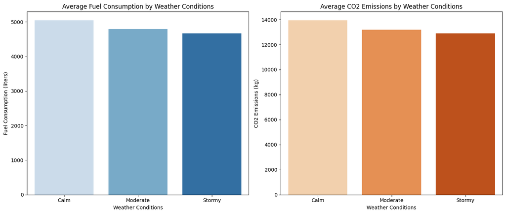

```python
# Group data by weather conditions and calculate averages for fuel consumption and CO2 emissions
weather_summary = data.groupby('weather_conditions')[['fuel_consumption', 'CO2_emissions']].mean().reset_index()

# Display summary table
print("Impact of Weather Conditions on Fuel Consumption and CO2 Emissions:")
display(weather_summary)

# Plot fuel consumption and CO2 emissions by weather conditions
fig, ax = plt.subplots(1, 2, figsize=(14, 6))

# Average Fuel Consumption by Weather Condition
sns.barplot(x='weather_conditions', y='fuel_consumption', data=weather_summary, palette='Blues', ax=ax[0])
ax[0].set_title('Average Fuel Consumption by Weather Conditions')
ax[0].set_xlabel('Weather Conditions')
ax[0].set_ylabel('Fuel Consumption (liters)')

# Average CO2 Emissions by Weather Condition
sns.barplot(x='weather_conditions', y='CO2_emissions', data=weather_summary, palette='Oranges', ax=ax[1])
ax[1].set_title('Average CO2 Emissions by Weather Conditions')
ax[1].set_xlabel('Weather Conditions')
ax[1].set_ylabel('CO2 Emissions (kg)')

plt.tight_layout()
plt.show()
```

# CO2 Emissions Per Kilometer by Fuel Type

In this section, we aim to answer the fifth research question: **"Which fuel type (HFO vs Diesel) has higher CO2 emissions per kilometer?"**

We will:

1. Calculate CO2 emissions per kilometer for each fuel type.
2. Compare the average CO2 emissions per kilometer between HFO and Diesel using a bar plot.

```
Average CO2 Emissions per Kilometer by Fuel Type:
```

|  | fuel_type | CO2_per_km |
| --- | --- | --- |
| 0 | Diesel | 72.774680 |
| 1 | HFO | 88.954892 |

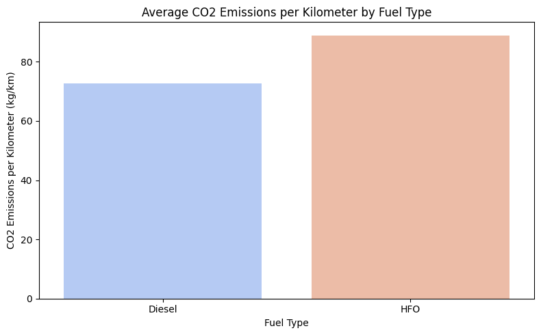

```python
# Create a new column for CO2 emissions per kilometer
data['CO2_per_km'] = data['CO2_emissions'] / data['distance']

# Group data by 'fuel_type' and calculate average CO2 emissions per kilometer
fuel_summary = data.groupby('fuel_type')['CO2_per_km'].mean().reset_index()

# Display the summary table
print("Average CO2 Emissions per Kilometer by Fuel Type:")
display(fuel_summary)

# Visualize CO2 emissions per kilometer by fuel type
plt.figure(figsize=(8, 5))
sns.barplot(x='fuel_type', y='CO2_per_km', data=fuel_summary, palette='coolwarm')
plt.title('Average CO2 Emissions per Kilometer by Fuel Type')
plt.xlabel('Fuel Type')
plt.ylabel('CO2 Emissions per Kilometer (kg/km)')
plt.tight_layout()
plt.show()
```

# Fuel Consumption Across Different Months

In this section, we aim to answer the sixth research question: **"How does fuel consumption change over different months?"**

We will:

1. Group the data by `month` and calculate the average fuel consumption.
2. Use a line plot to visualize monthly trends in fuel consumption.

```
Average Fuel Consumption by Month:
```

|  | month | fuel_consumption |
| --- | --- | --- |
| 4 | January | 4823.221000 |
| 3 | February | 5155.879083 |
| 7 | March | 5412.323333 |
| 0 | April | 5377.724917 |
| 8 | May | 5247.213583 |
| 6 | June | 4599.133250 |
| 5 | July | 5126.767917 |
| 1 | August | 3976.523250 |
| 11 | September | 4695.087167 |
| 10 | October | 4531.740000 |
| 9 | November | 4777.184333 |
| 2 | December | 4408.160583 |

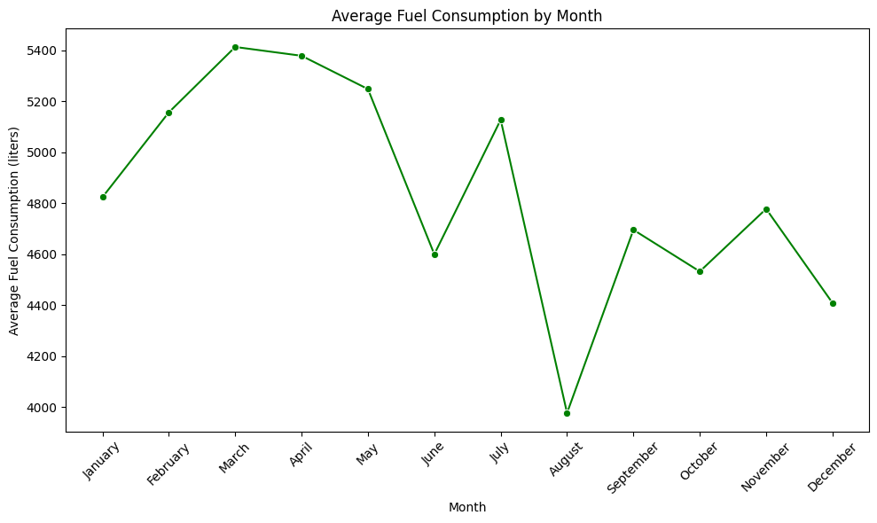

```python
# Group data by 'month' and calculate average fuel consumption
monthly_summary = data.groupby('month')['fuel_consumption'].mean().reset_index()

# Sort the months in calendar order
month_order = ['January', 'February', 'March', 'April', 'May', 'June',
               'July', 'August', 'September', 'October', 'November', 'December']
monthly_summary['month'] = pd.Categorical(monthly_summary['month'], categories=month_order, ordered=True)
monthly_summary = monthly_summary.sort_values('month')

# Display the summary table
print("Average Fuel Consumption by Month:")
display(monthly_summary)

# Visualize average fuel consumption over months
plt.figure(figsize=(10, 6))
sns.lineplot(x='month', y='fuel_consumption', data=monthly_summary, marker='o', color='green')
plt.title('Average Fuel Consumption by Month')
plt.xlabel('Month')
plt.ylabel('Average Fuel Consumption (liters)')
plt.xticks(rotation=45)
plt.tight_layout()
plt.show()
```

# Conclusion